# Supplementary Material for Goodness-of-Fit Checks for Joint Models

Dimitris Rizopoulos, Jeremy M.G. Taylor and Isabella Kardys

# 1 Bio-SHiFT Data Analysis

## 1.1 Summary

This section details the application of the joint modeling framework to a clinical dataset of patients with chronic heart failure. The primary objective is to investigate how the temporal evolution of two biomarkers, eGFR and NGAL, relates to the risk of a composite clinical endpoint. This composite endpoint includes heart failure hospitalization, cardiac death, left ventricular assist device placement, and heart transplantation.

- Model Specifications: The analysis explores four bivariate joint models built from different combinations of longitudinal and survival submodels. The longitudinal submodels test both linear and nonlinear (natural cubic spline) subject-specific evolutions. The survival submodels test two functional forms: one linking the current biomarker value to the event risk, and another linking the average biomarker value over time to the event risk.
- Evaluation Methodology: The fit of these four models is evaluated using posterior-posterior predictive checks, posterior-prior checks, and 10-fold cross-validation.
- Key Findings: Standard information criteria (DIC, WAIC, and LPML) do not uniformly agree on the best model. However, the predictive checks reveal that nonlinear trajectory models better describe the mean function, and that the NGAL model provides a better overall fit than the eGFR model. Furthermore, the area/integral functional form yields a stronger association fit for eGFR.

## 1.2 Descriptive Statistics

| **Characteristic** | **N = 263**<sup>1</sup> |
| --- | --- |
| AGE | 66.7 (12.6; [28.4, 88.0]) |
| SEX |  |
| female | 74 (28%) |
| male | 189 (72%) |
| NYHA123 |  |
| 1 | 77 (29%) |
| >1 | 186 (71%) |
| DM | 81 (31%) |
| IHD | 117 (44%) |
| Diuretics | 237 (90%) |

<sup>1</sup> Mean (SD; [Min, Max]); n (%)

## 1.3 Descriptive Figures

- Sample Means: per longitudinal outcome; the red superimposed line is the LOESS curve.
- Sample Patients: longitudinal trajectories from 25 randomly selected patients; patient numbers with an asterisk denote patients who experienced the composite endpoint.

### 1.3.1 Sample Means

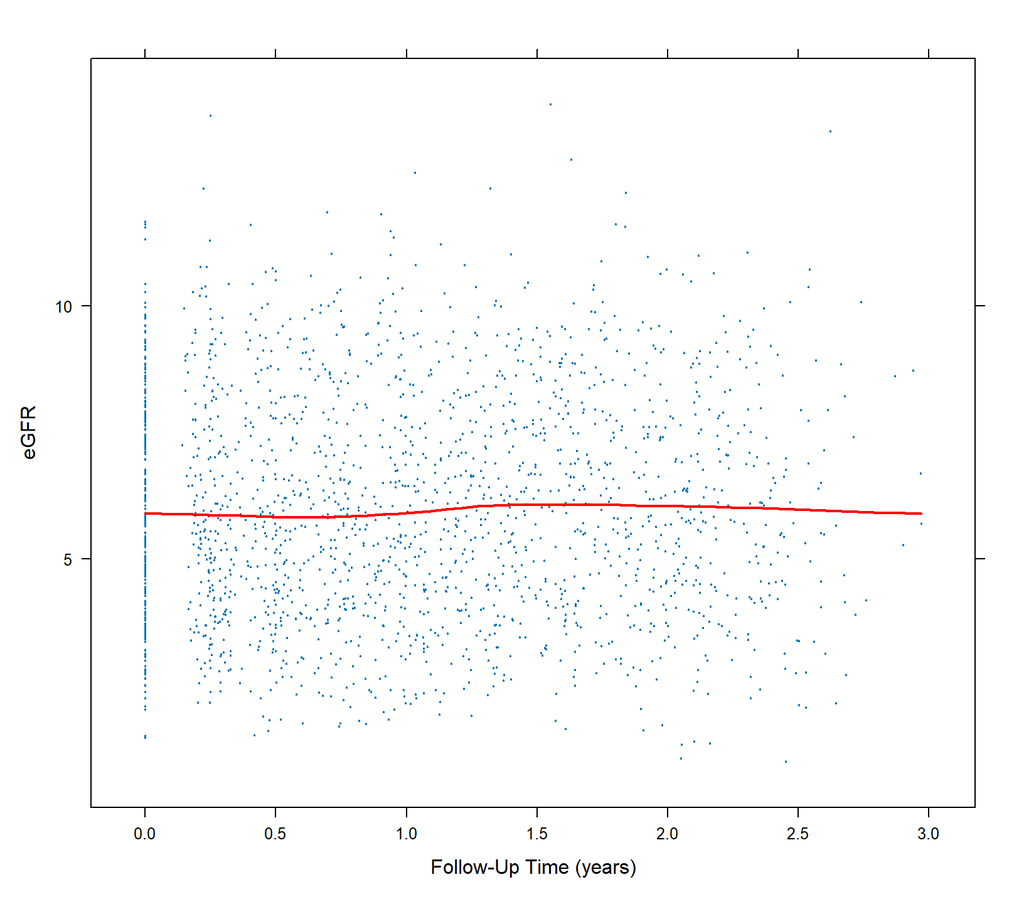

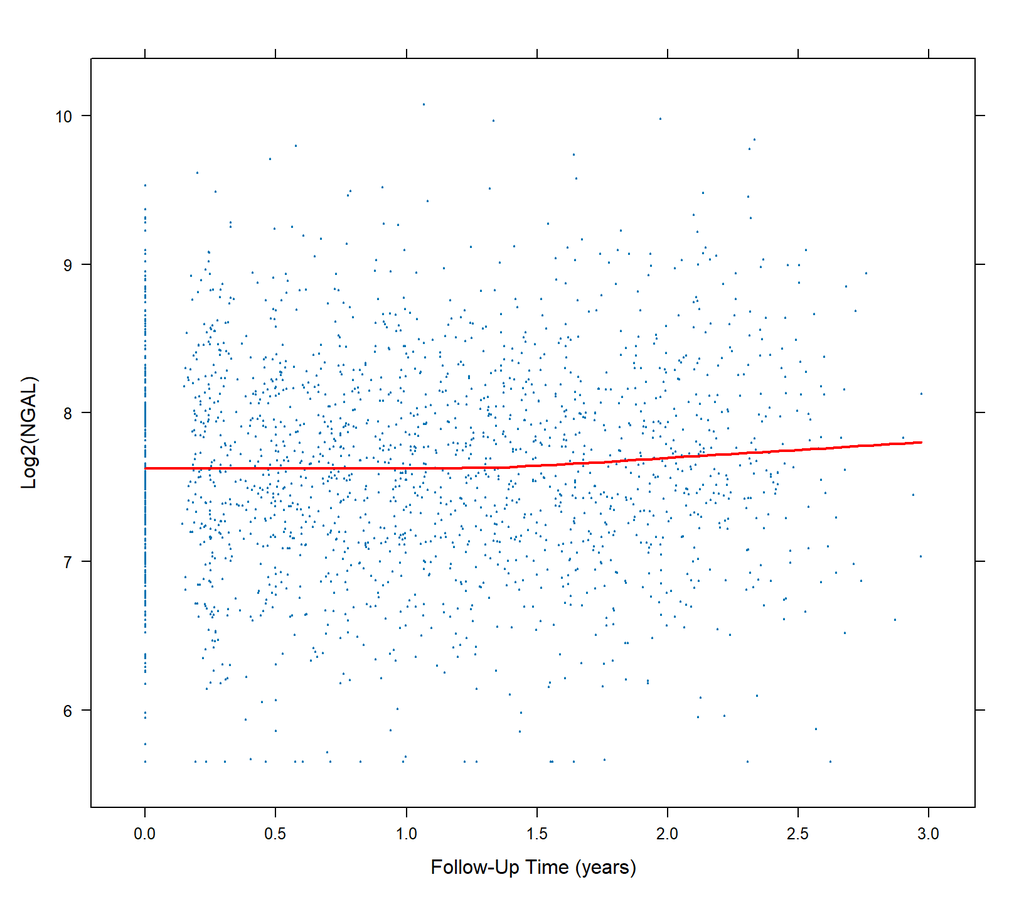

### 1.3.2 Sample Patients

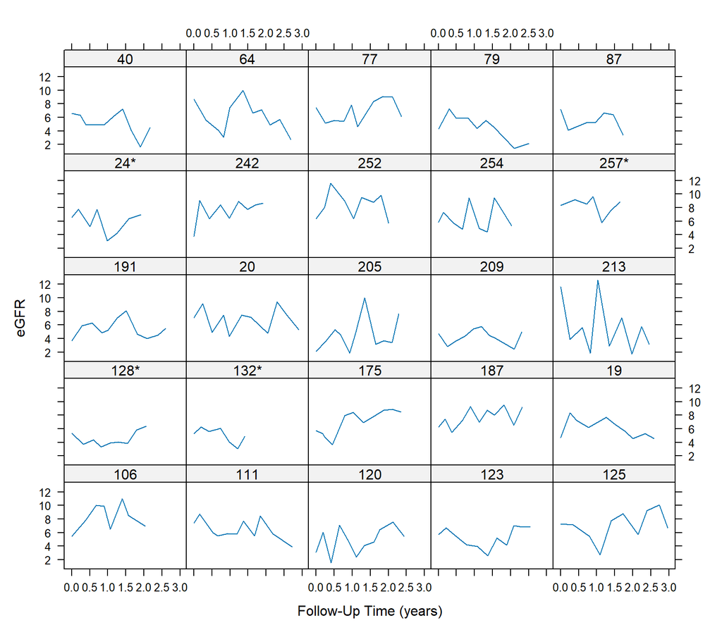

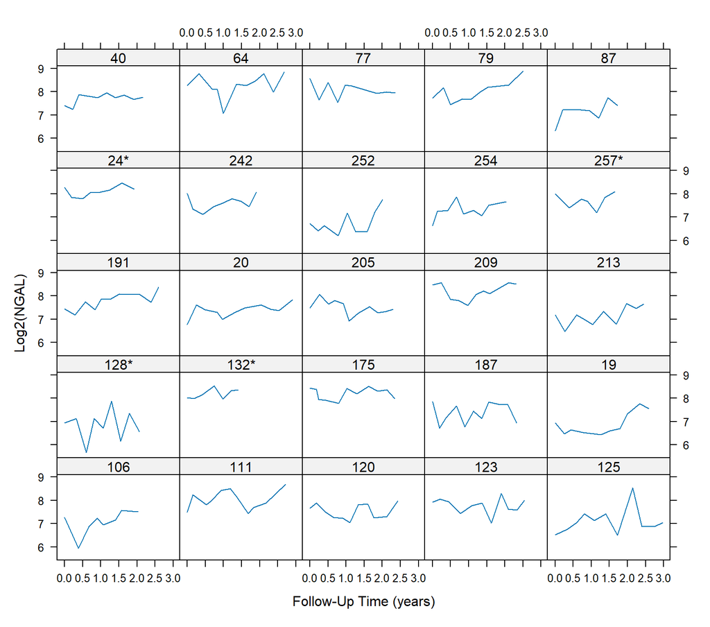

### 1.3.3 Kaplan Meier Estimate Composite Endpoint

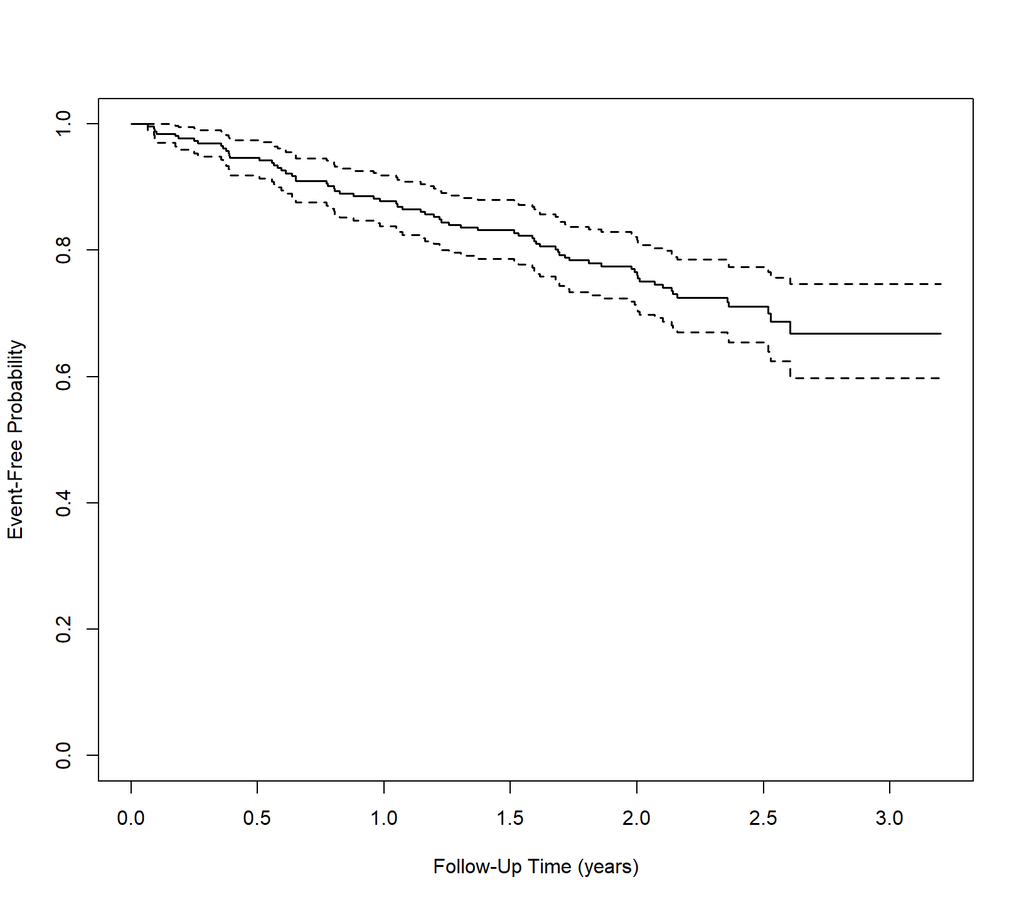

## 1.4 Parameter Estimates and Information Criteria

- The four models fitted to the Bio-SHiFT data are
  - `jFit_lin_val`: linear fixed and random effects structure, current value functional form.
  - `jFit_lin_area`: linear fixed and random effects structure, area/integral functional form.
  - `jFit_nonlin_val`: nonlinear (splines) fixed and random effects structure, current value functional form.
  - `jFit_nonlin_area`: nonlinear (splines) fixed and random effects structure, area/integral functional form.
- We show parameter estimates and 95% credible intervals for each fitted joint model. For the survival submodel, hazard ratios (the exponent of the corresponding regression coefficients) are presented.
- Comparison: The Deviance Information Criterion (DIC), the Watanabe-Akaike information criterion (WAIC), and the log pseudo marginal likelihood (LPML) for the fitted joint models. For DIC and WAIC smaller values are better, whereas for LPML larger values are better.

### 1.4.1 Linear Mixed Models - Value functional Form

Hazard ratios (95% credible intervals) for the survival submodel from the joint models with linear longitudinal submodels and the value functional form.

|  | HR (95% CI) |
| --- | --- |
| AGE | 0.99 (0.96; 1.02) |
| SEX | 0.97 (0.47; 2.00) |
| NYHA123 | 1.97 (1.41; 2.82) |
| DM | 1.52 (0.93; 2.53) |
| IHD | 1.30 (0.78; 2.21) |
| Diuretics | 3.18 (0.82; 20.62) |
| value(eGFR_CKDEPI_per10) | 1.14 (0.80; 1.66) |
| value(Log2_NGAL_P) | 3.04 (1.66; 5.69) |

Posterior Means (95% credible intervals) for the eGFR submodel, from the joint models with linear longitudinal submodels and the value functional form.

|  | Estimate (95% CI) |
| --- | --- |
| (Intercept) | 10.52 (9.50; 11.55) |
| OBSTIME_YEAR | 0.05 (-0.08; 0.18) |
| AGE | -0.07 (-0.08; -0.05) |
| SEX | 0.92 (0.55; 1.29) |
| NYHA123 | -0.01 (-0.24; 0.22) |
| DM | -0.36 (-0.72; -0.01) |
| IHD | 0.42 (0.07; 0.76) |
| Diuretics | -0.90 (-1.44; -0.36) |
| sigma | 1.61 (1.55; 1.67) |

Posterior Means (95% credible intervals) for the NGAL submodel, from the joint models with linear longitudinal submodels and the value functional form

|  | Estimate (95% CI) |
| --- | --- |
| (Intercept) | 5.67 (5.21; 6.12) |
| OBSTIME_YEAR | 0.11 (0.08; 0.14) |
| AGE | 0.02 (0.01; 0.02) |
| SEX | 0.15 (-0.02; 0.31) |
| NYHA123 | 0.14 (0.04; 0.24) |
| DM | 0.16 (0.00; 0.32) |
| IHD | -0.10 (-0.26; 0.05) |
| Diuretics | 0.31 (0.06; 0.55) |
| sigma | 0.39 (0.38; 0.41) |

### 1.4.2 Linear Mixed Models - Area functional Form

Hazard ratios (95% credible intervals) for the survival submodel from the joint models with linear longitudinal submodels and the area functional form.

|  | HR (95% CI) |
| --- | --- |
| AGE | 0.99 (0.96; 1.03) |
| SEX | 0.95 (0.47; 1.90) |
| NYHA123 | 1.97 (1.39; 2.83) |
| DM | 1.53 (0.94; 2.53) |
| IHD | 1.29 (0.76; 2.17) |
| Diuretics | 3.08 (0.81; 18.14) |
| area(eGFR_CKDEPI_per10) | 1.16 (0.82; 1.67) |
| area(Log2_NGAL_P) | 3.02 (1.69; 5.62) |

Posterior Means (95% credible intervals) for the eGFR submodel, from the joint models with linear longitudinal submodels and the area functional form.

|  | Estimate (95% CI) |
| --- | --- |
| (Intercept) | 10.51 (9.47; 11.57) |
| OBSTIME_YEAR | 0.05 (-0.08; 0.18) |
| AGE | -0.07 (-0.08; -0.05) |
| SEX | 0.92 (0.53; 1.30) |
| NYHA123 | -0.01 (-0.24; 0.22) |
| DM | -0.36 (-0.73; -0.01) |
| IHD | 0.42 (0.07; 0.77) |
| Diuretics | -0.90 (-1.45; -0.36) |
| sigma | 1.61 (1.55; 1.66) |

Posterior Means (95% credible intervals) for the NGAL submodel, from the joint models with linear longitudinal submodels and the area functional form

|  | Estimate (95% CI) |
| --- | --- |
| (Intercept) | 5.67 (5.21; 6.12) |
| OBSTIME_YEAR | 0.11 (0.08; 0.14) |
| AGE | 0.02 (0.01; 0.02) |
| SEX | 0.15 (-0.01; 0.31) |
| NYHA123 | 0.14 (0.04; 0.24) |
| DM | 0.16 (0.01; 0.32) |
| IHD | -0.10 (-0.26; 0.05) |
| Diuretics | 0.31 (0.06; 0.55) |
| sigma | 0.39 (0.38; 0.41) |

### 1.4.3 Nonlinear Mixed Models - Value functional Form

Hazard ratios (95% credible intervals) for the survival submodel from the joint models with nonlinear longitudinal submodels and the value functional form.

|  | HR (95% CI) |
| --- | --- |
| AGE | 1.00 (0.97; 1.03) |
| SEX | 0.90 (0.44; 1.85) |
| NYHA123 | 1.98 (1.39; 2.82) |
| DM | 1.54 (0.94; 2.55) |
| IHD | 1.29 (0.77; 2.17) |
| Diuretics | 3.15 (0.83; 18.05) |
| value(eGFR_CKDEPI_per10) | 1.21 (0.88; 1.71) |
| value(Log2_NGAL_P) | 3.12 (1.74; 5.68) |

Posterior Means (95% credible intervals) for the eGFR submodel, from the joint models with nonlinear longitudinal submodels and the value functional form.

|  | Estimate (95% CI) |
| --- | --- |
| (Intercept) | 10.40 (9.39; 11.44) |
| ns(OBSTIME_YEAR, 3, B = c(0, 3.2))1 | 0.59 (0.17; 1.02) |
| ns(OBSTIME_YEAR, 3, B = c(0, 3.2))2 | -0.46 (-1.03; 0.11) |
| ns(OBSTIME_YEAR, 3, B = c(0, 3.2))3 | -0.61 (-1.31; 0.09) |
| AGE | -0.07 (-0.08; -0.05) |
| SEX | 0.95 (0.56; 1.32) |
| NYHA123 | 0.02 (-0.22; 0.24) |
| DM | -0.37 (-0.73; -0.01) |
| IHD | 0.37 (0.01; 0.71) |
| Diuretics | -0.85 (-1.39; -0.31) |
| sigma | 1.58 (1.52; 1.64) |

Posterior Means (95% credible intervals) for the NGAL submodel, from the joint models with nonlinear longitudinal submodels and the value functional form

|  | Estimate (95% CI) |
| --- | --- |
| (Intercept) | 5.72 (5.28; 6.16) |
| ns(OBSTIME_YEAR, 3, B = c(0, 3.2))1 | 0.06 (-0.05; 0.15) |
| ns(OBSTIME_YEAR, 3, B = c(0, 3.2))2 | 0.37 (0.14; 0.47) |
| ns(OBSTIME_YEAR, 3, B = c(0, 3.2))3 | 0.54 (0.34; 0.69) |
| AGE | 0.02 (0.01; 0.02) |
| SEX | 0.15 (-0.02; 0.31) |
| NYHA123 | 0.13 (0.04; 0.23) |
| DM | 0.17 (0.01; 0.32) |
| IHD | -0.10 (-0.25; 0.06) |
| Diuretics | 0.30 (0.06; 0.55) |
| sigma | 0.38 (0.37; 0.40) |

### 1.4.4 Nonlinear Mixed Models - Area functional Form

Hazard ratios (95% credible intervals) for the survival submodel from the joint models with nonlinear longitudinal submodels and the area functional form.

|  | HR (95% CI) |
| --- | --- |
| AGE | 0.99 (0.96; 1.02) |
| SEX | 1.00 (0.50; 2.00) |
| NYHA123 | 1.98 (1.39; 2.80) |
| DM | 1.51 (0.92; 2.48) |
| IHD | 1.32 (0.78; 2.19) |
| Diuretics | 2.98 (0.79; 17.12) |
| area(eGFR_CKDEPI_per10) | 1.11 (0.80; 1.54) |
| area(Log2_NGAL_P) | 2.81 (1.60; 5.03) |

Posterior Means (95% credible intervals) for the eGFR submodel, from the joint models with nonlinear longitudinal submodels and the area functional form.

|  | Estimate (95% CI) |
| --- | --- |
| (Intercept) | 10.42 (9.39; 11.48) |
| ns(OBSTIME_YEAR, 3, B = c(0, 3.2))1 | 0.58 (0.14; 1.00) |
| ns(OBSTIME_YEAR, 3, B = c(0, 3.2))2 | -0.48 (-1.00; 0.08) |
| ns(OBSTIME_YEAR, 3, B = c(0, 3.2))3 | -0.62 (-1.31; 0.06) |
| AGE | -0.07 (-0.08; -0.05) |
| SEX | 0.95 (0.57; 1.31) |
| NYHA123 | 0.01 (-0.22; 0.24) |
| DM | -0.37 (-0.73; -0.01) |
| IHD | 0.37 (0.02; 0.72) |
| Diuretics | -0.85 (-1.39; -0.30) |
| sigma | 1.58 (1.52; 1.64) |

Posterior Means (95% credible intervals) for the NGAL submodel, from the joint models with nonlinear longitudinal submodels and the area functional form

|  | Estimate (95% CI) |
| --- | --- |
| (Intercept) | 5.72 (5.27; 6.16) |
| ns(OBSTIME_YEAR, 3, B = c(0, 3.2))1 | 0.05 (-0.05; 0.15) |
| ns(OBSTIME_YEAR, 3, B = c(0, 3.2))2 | 0.39 (0.20; 0.49) |
| ns(OBSTIME_YEAR, 3, B = c(0, 3.2))3 | 0.55 (0.37; 0.71) |
| AGE | 0.02 (0.01; 0.02) |
| SEX | 0.15 (-0.01; 0.31) |
| NYHA123 | 0.13 (0.04; 0.23) |
| DM | 0.17 (0.01; 0.33) |
| IHD | -0.10 (-0.25; 0.06) |
| Diuretics | 0.30 (0.06; 0.55) |
| sigma | 0.38 (0.37; 0.40) |

### 1.4.5 Comparison

Deviance information criterion (DIC), Watanabe-Akaike information criterion (WAIC), and log pseudo marginal likelihood (LPML) for the four fitted joint models.

|  | Model | DIC | WAIC | LPML |
| --- | --- | --- | --- | --- |
| 4 | Nonlinear-Area | 10765.51 | 10995.24 | -5526.914 |
| 3 | Nonlinear-Value | 10756.25 | 11013.66 | -5550.674 |
| 2 | Linear-Area | 11120.21 | 11113.62 | -5607.279 |
| 1 | Linear-Value | 11117.45 | 11116.76 | -5601.697 |

## 1.5 Longitudinal Models: Posterior-Posterior Checks

- The four tabs show the empirical cumulative distribution, mean, variance, and semi-variogram functions for the two fitted joint models using the current value functional form. The results from the area/integral functional form were very similar.
- In each figure and for the two longitudinal outcomes, we compare the observed data metric (black line) with the same metric calculated in 50 simulated datasets from the corresponding model (grey lines).

### 1.5.1 ECDF

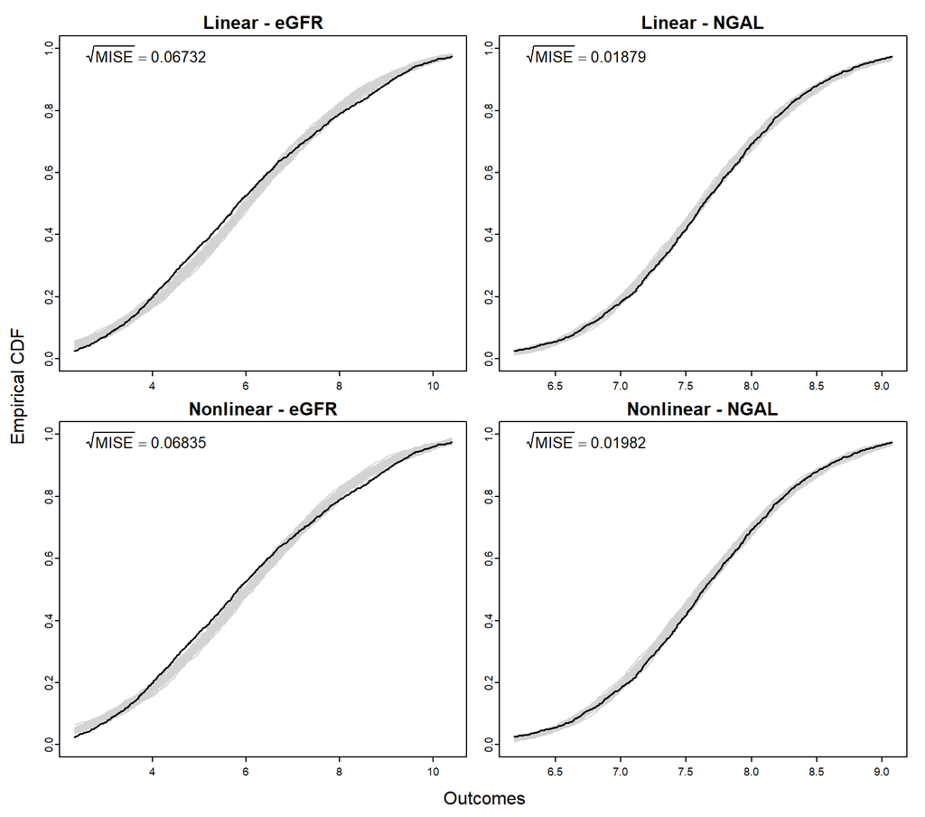

### 1.5.2 Mean Function

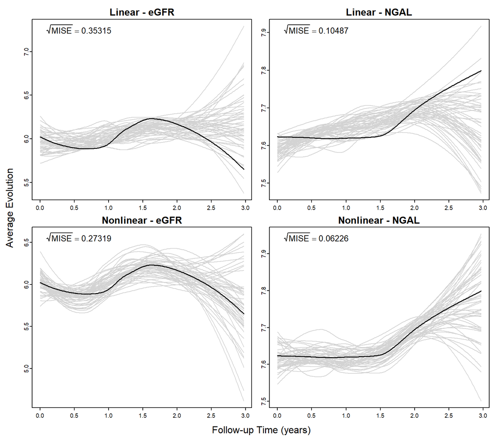

### 1.5.3 Variance Function

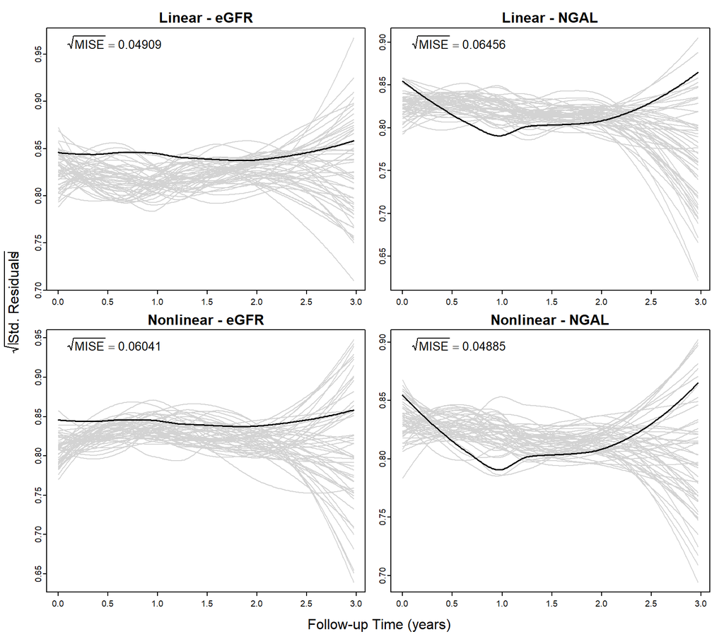

### 1.5.4 Correlation Structure

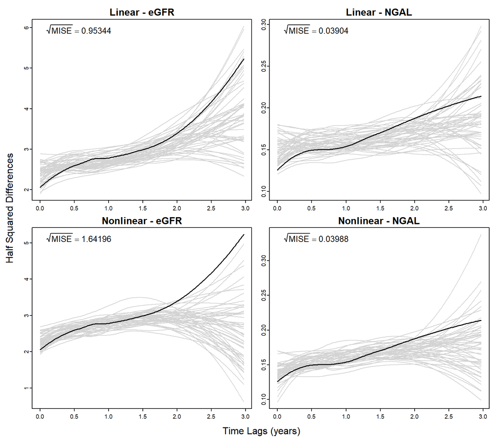

## 1.6 Longitudinal Models: Posterior-Posterior Checks - transformed eGFR

- The four tabs show the empirical cumulative distribution, mean, variance, and semi-variogram functions from the joint model with a mixed-effects model for the square root transformation of eGFR with Student’s t error terms with four degrees of freedom. For NGAL the linear mixed model was used. In both models, the subject-specific profiles are modeled with natural cubic splines. The value functional form is use the survival submodel.
- In each figure and for the two longitudinal outcomes, we compare the observed data metric (black line) with the same metric calculated in 50 simulated datasets from the corresponding model (grey lines).

### 1.6.1 ECDF

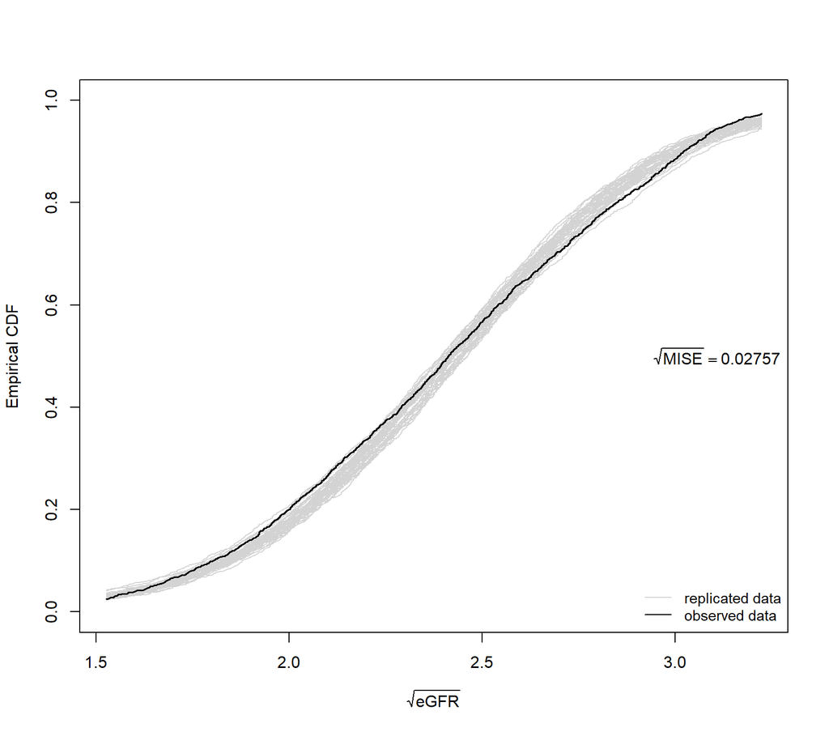

### 1.6.2 Mean Function

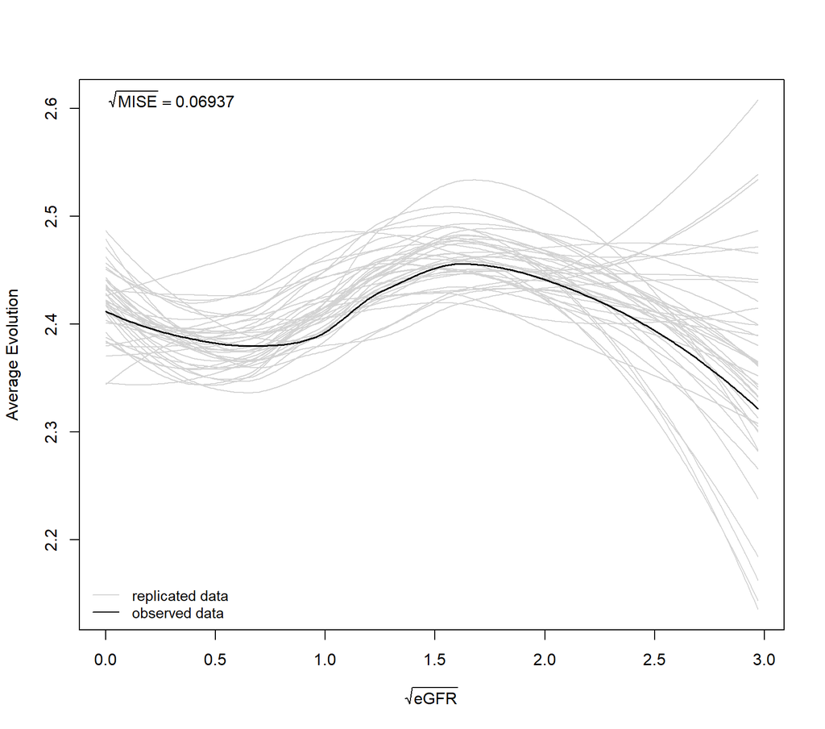

### 1.6.3 Variance Function

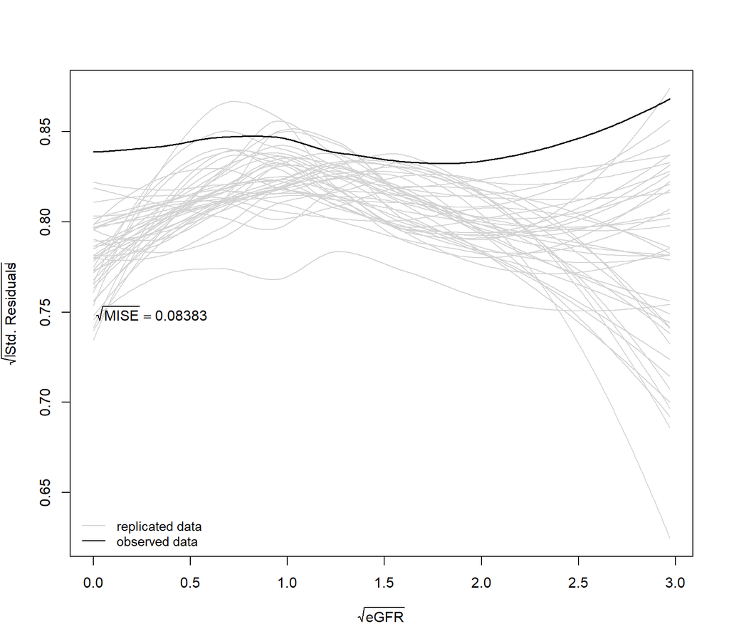

### 1.6.4 Correlation Structure

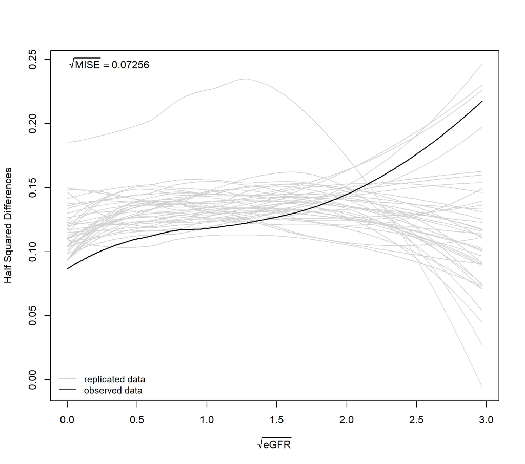

## 1.7 Longitudinal Models: Posterior-Prior Checks

- The four tabs show the empirical cumulative distribution, mean, variance, and semi-variogram functions for the two fitted joint models using the current value functional form. The results from the area/integral functional form were very similar.
- In each figure and for the two longitudinal outcomes, and for the two longitudinal outcomes, we compare the observed data metric (black line) with the same metric calculated in 50 simulated datasets from the corresponding model (grey lines).

### 1.7.1 ECDF

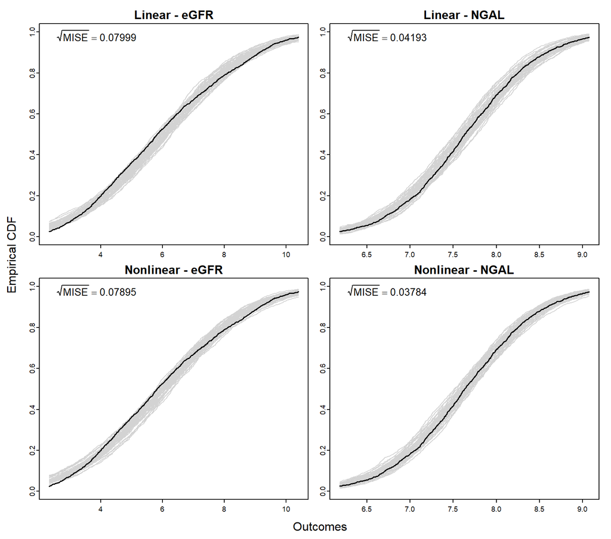

### 1.7.2 Mean Function

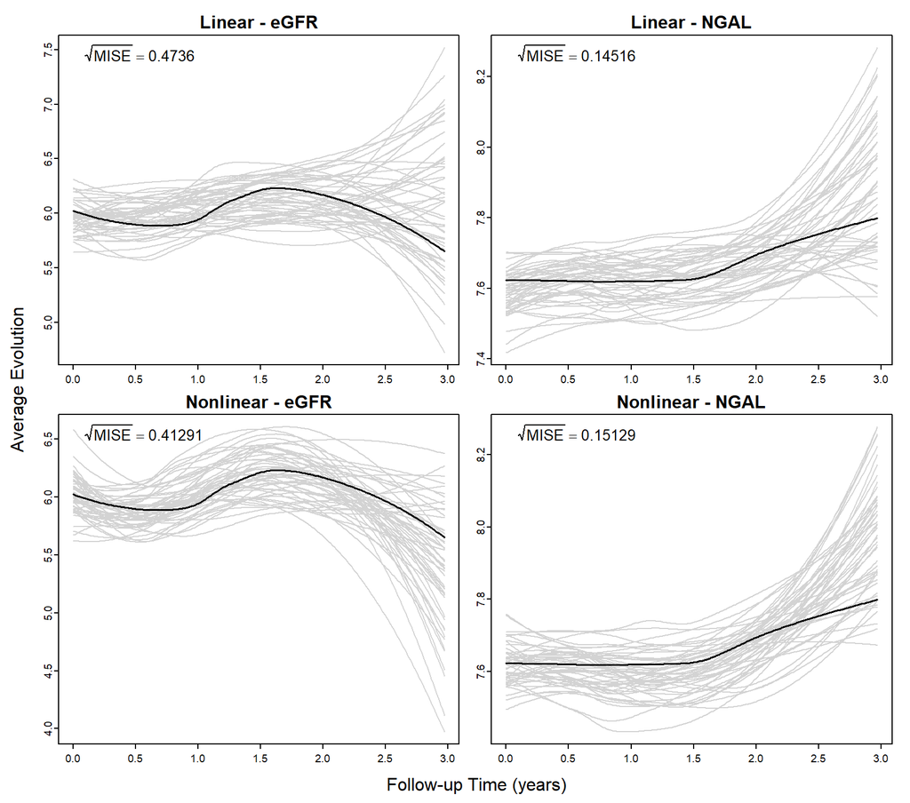

### 1.7.3 Variance Function

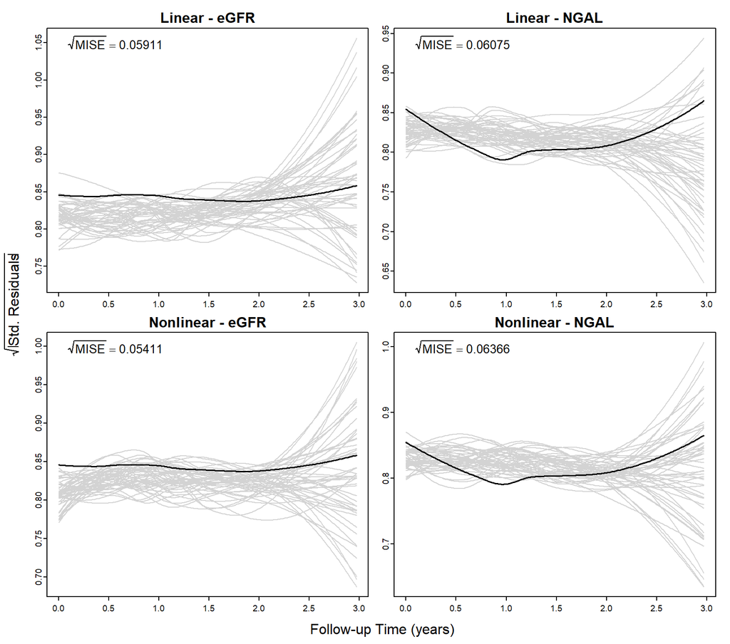

### 1.7.4 Correlation Structure

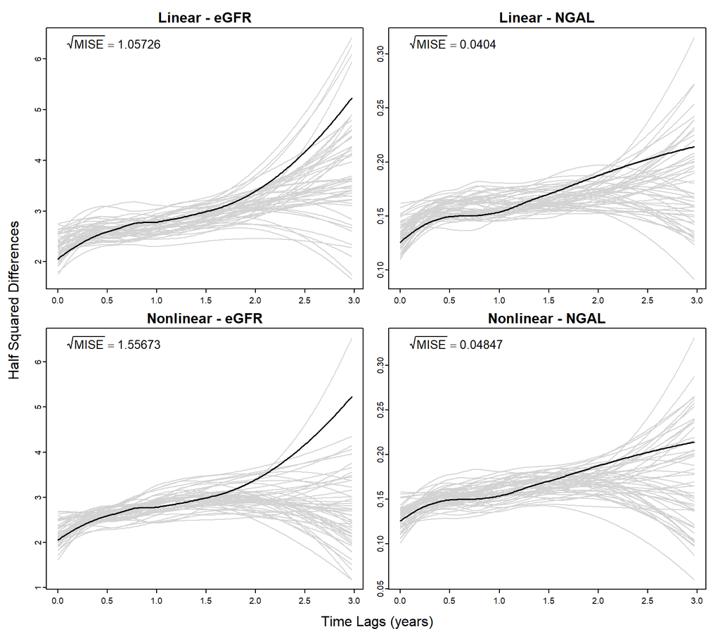

## 1.8 Longitudinal Models: Cross-Validated Posterior-Prior Checks

- The four tabs show the empirical cumulative distribution, mean, variance, and semi-variogram functions for the two fitted joint models using the current value functional form. The results from the area/integral functional form were very similar.
- In each figure and for the two longitudinal outcomes, we compare the observed data metric (black line) with the same metric calculated in 50 simulated datasets from the corresponding model (grey lines).
- The simulated datasets have been generated using the cross-validation procedure described in the main paper using $V = 10$ folds.

### 1.8.1 ECDF

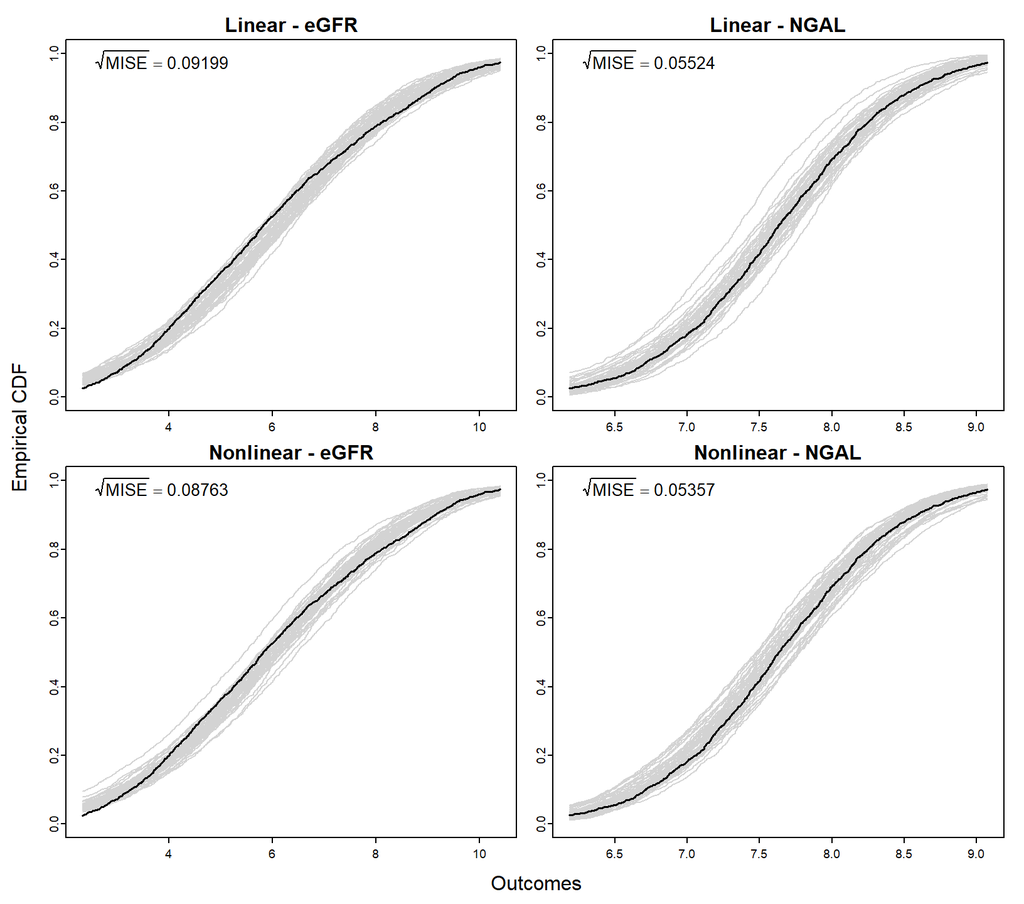

### 1.8.2 Mean Function

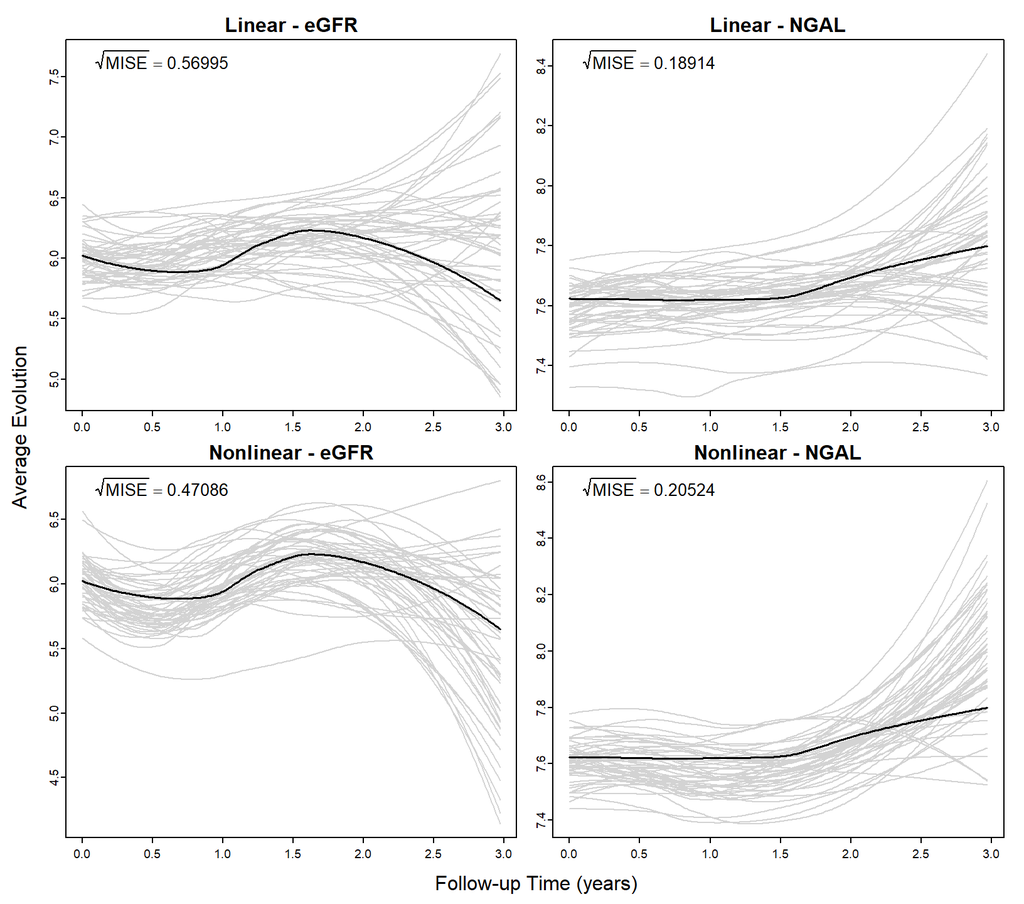

### 1.8.3 Variance Function

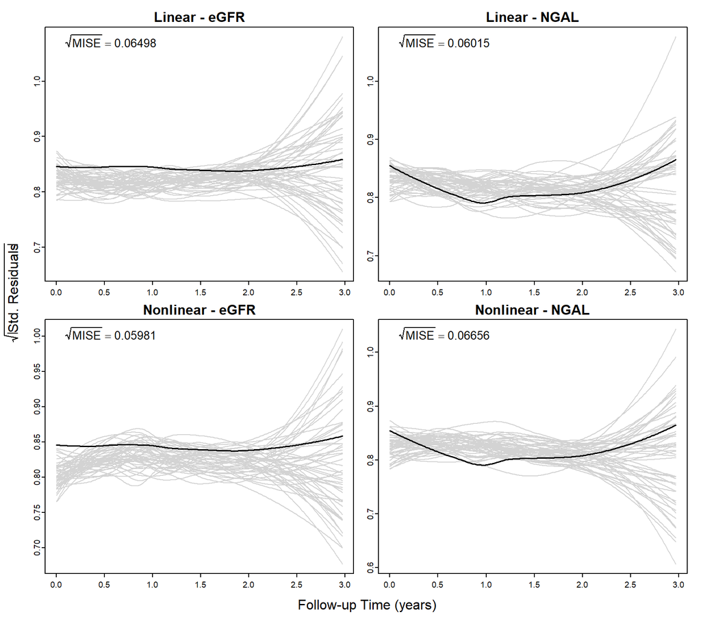

### 1.8.4 Correlation Structure

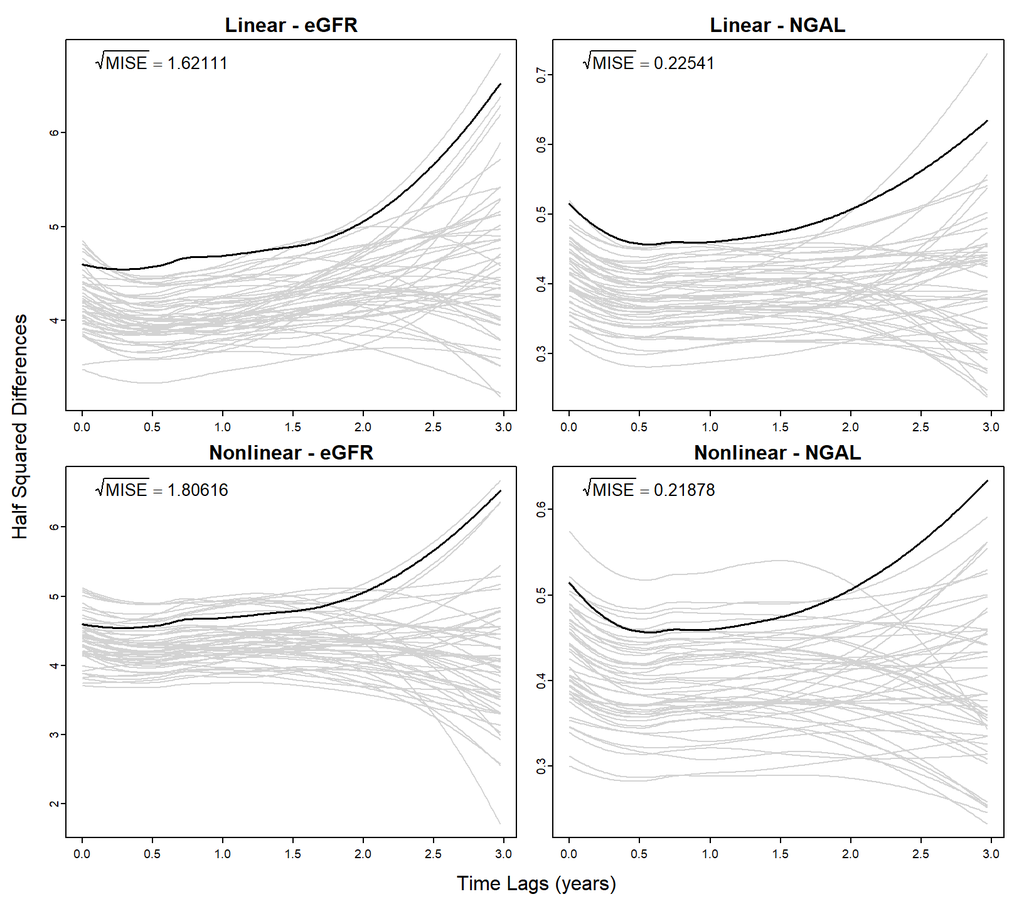

## 1.9 Longitudinal Models: Cross-Validated Dynamic-Posterior-Posterior Checks at landmark time t_L = 1

- The four tabs show the empirical cumulative distribution, mean, variance, and semi-variogram functions for the two fitted joint models using the current value functional form. The results from the area/integral functional form were very similar.
- In each figure and for the two longitudinal outcomes, we compare the observed data metric (black line) with the same metric calculated in 50 simulated datasets from the corresponding model (grey lines) using longitudinal information up to the landmark time $t_L = 1$ year.
- The simulated datasets have been generated using the cross-validation procedure described in the main paper using $V = 10$ folds.

### 1.9.1 ECDF

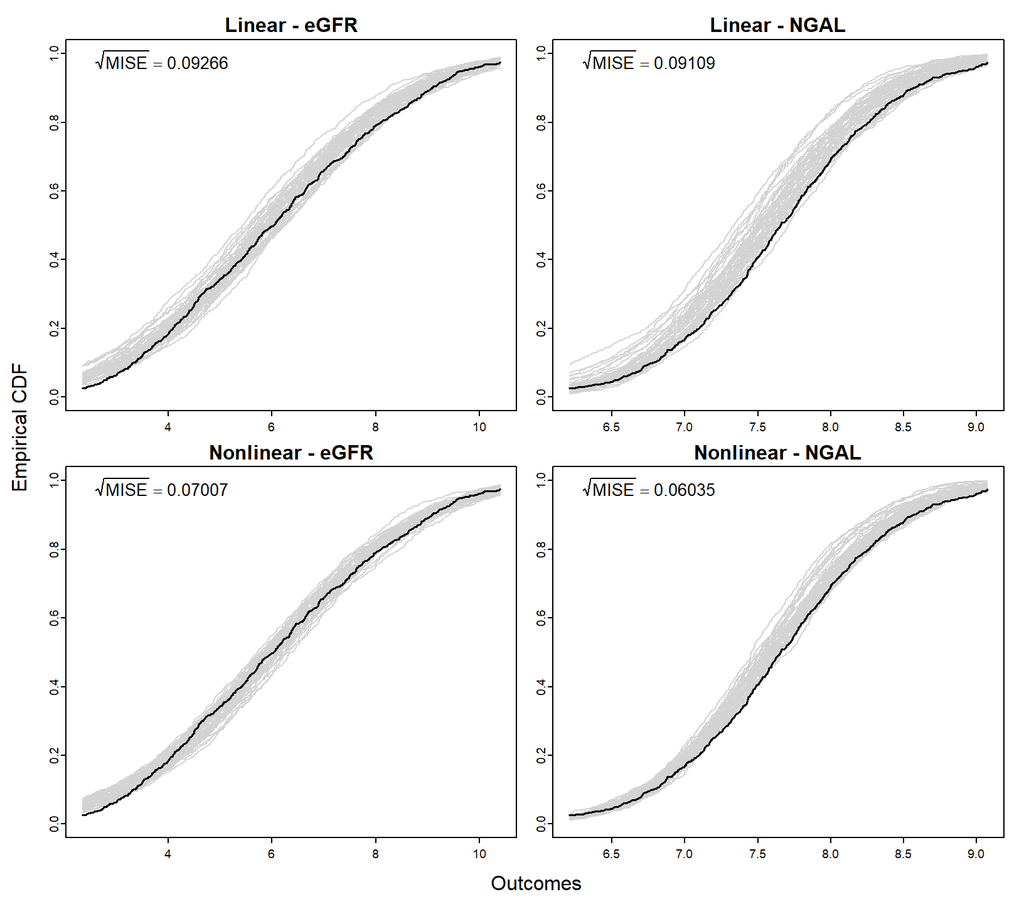

### 1.9.2 Mean Function

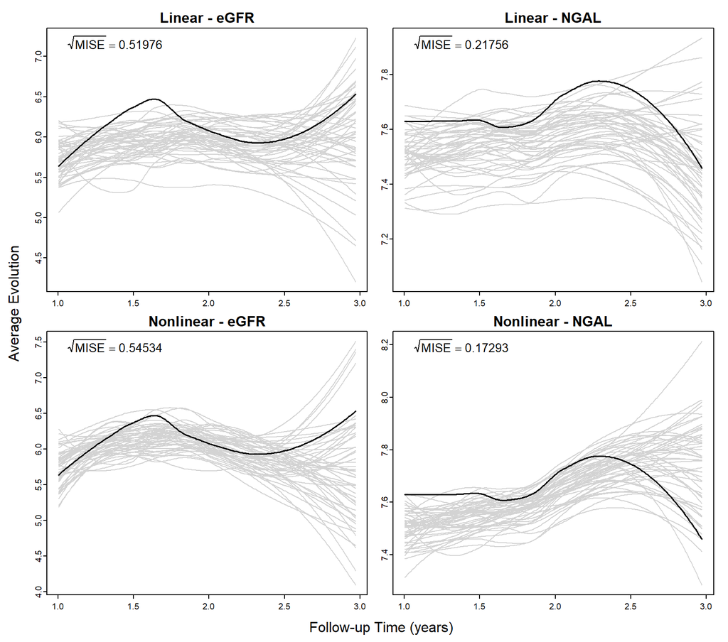

### 1.9.3 Variance Function

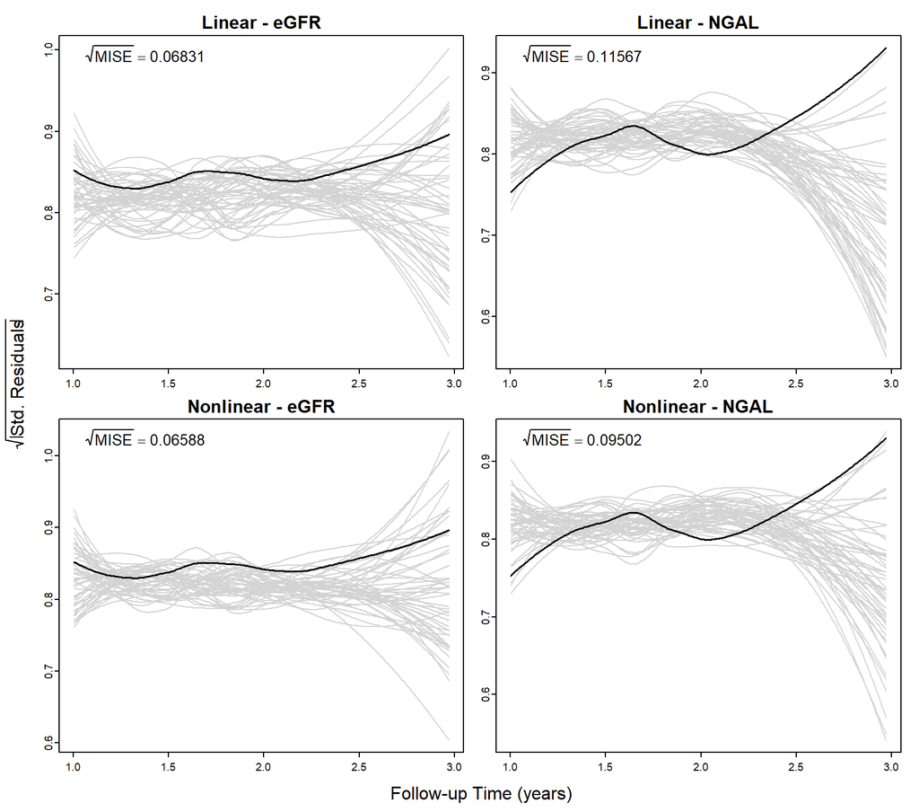

### 1.9.4 Correlation Structure

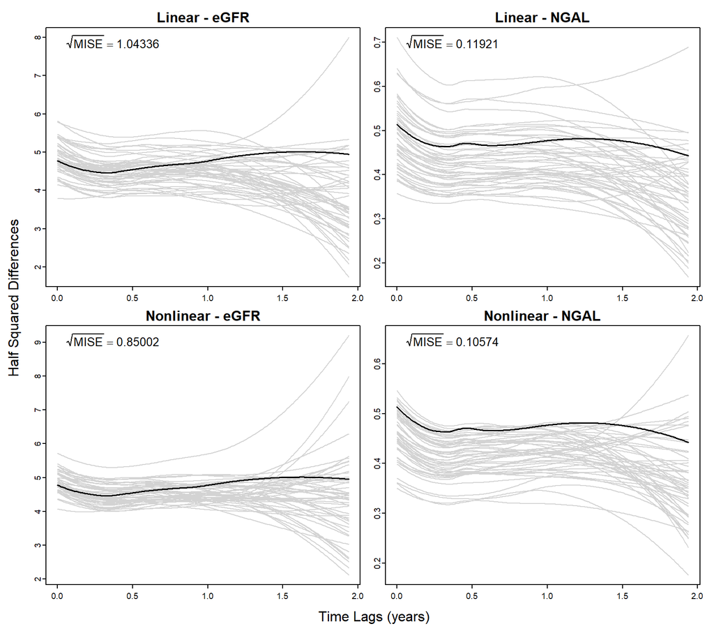

## 1.10 Longitudinal Models: Cross-Validated Dynamic-Posterior-Posterior Checks at landmark time t_L = 1.5

- The four tabs show the empirical cumulative distribution, mean, variance, and semi-variogram functions for the two fitted joint models using the current value functional form. The results from the area/integral functional form were very similar.
- In each figure and for the two longitudinal outcomes, we compare the observed data metric (black line) with the same metric calculated in 50 simulated datasets from the corresponding model (grey lines) using longitudinal information up to the landmark time $t_L = 1.5$ years.
- The simulated datasets have been generated using the cross-validation procedure described in the main paper using $V = 10$ folds.

### 1.10.1 ECDF

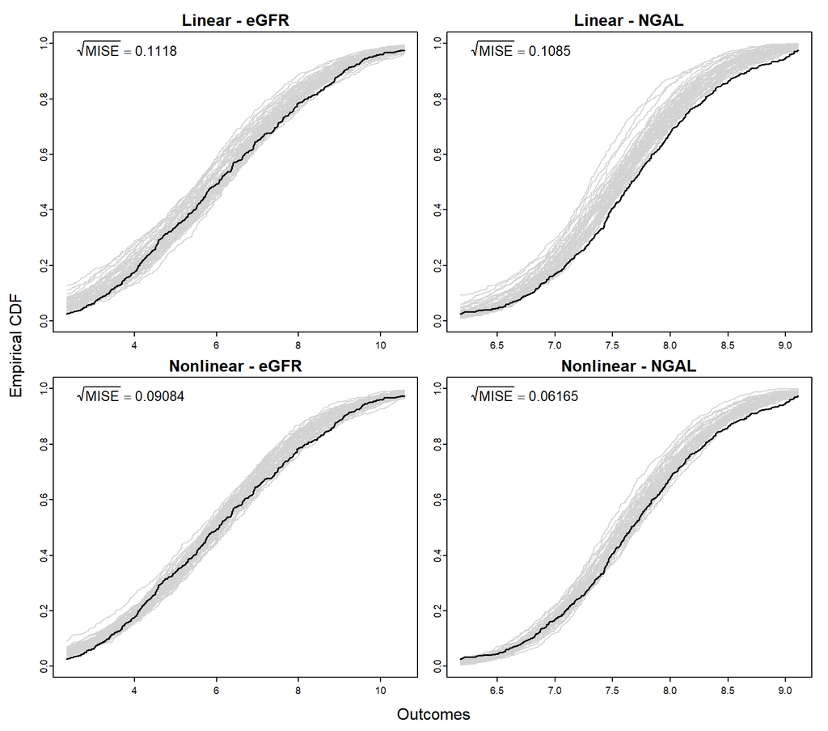

### 1.10.2 Mean Function

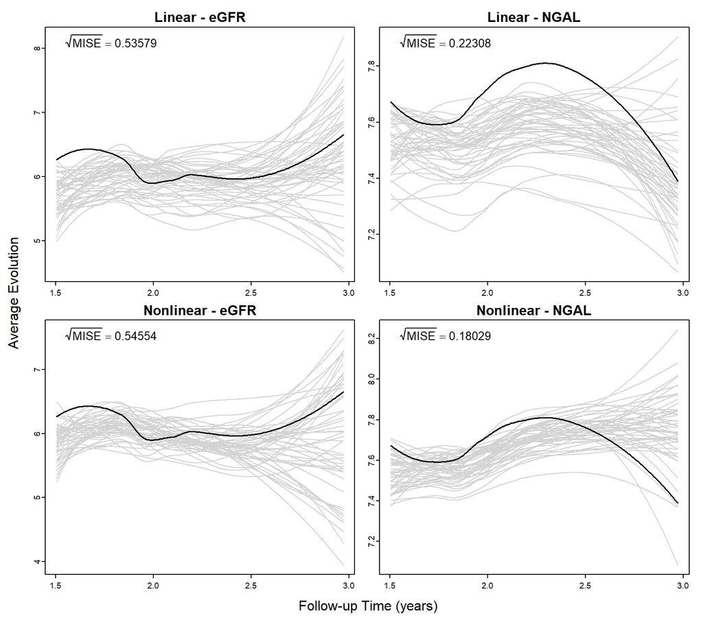

### 1.10.3 Variance Function

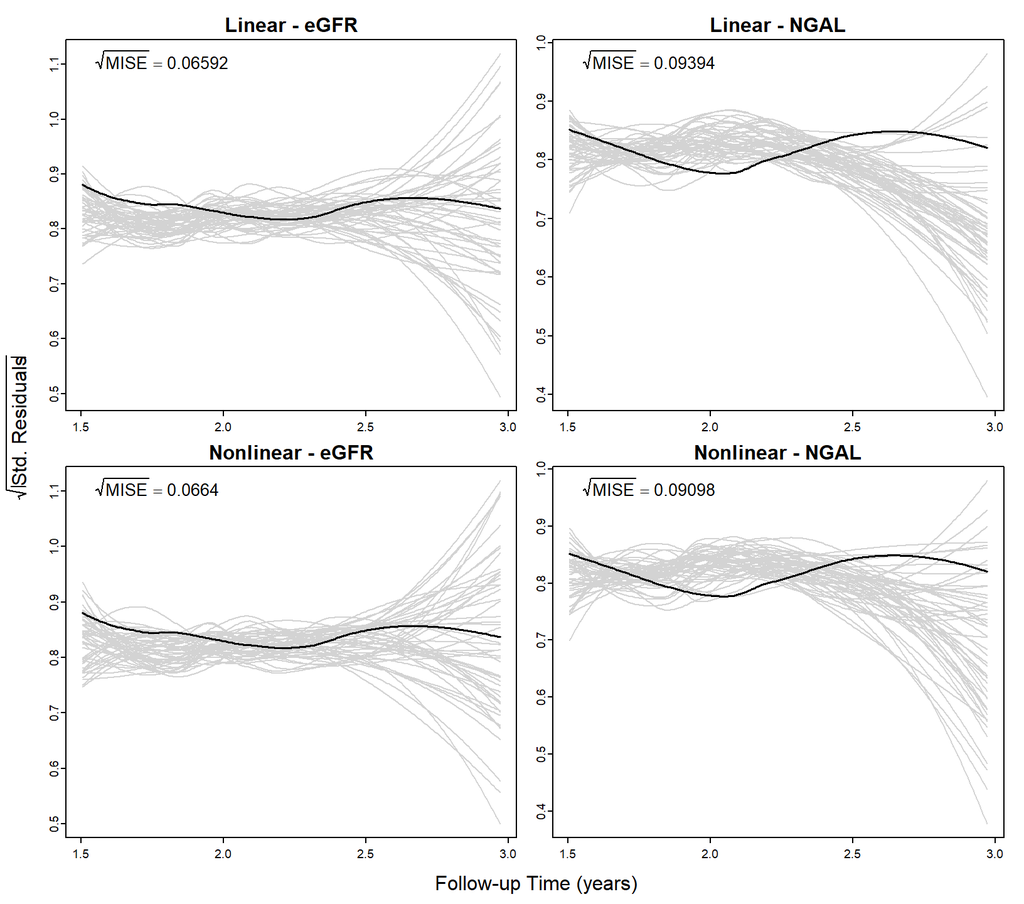

### 1.10.4 Correlation Structure

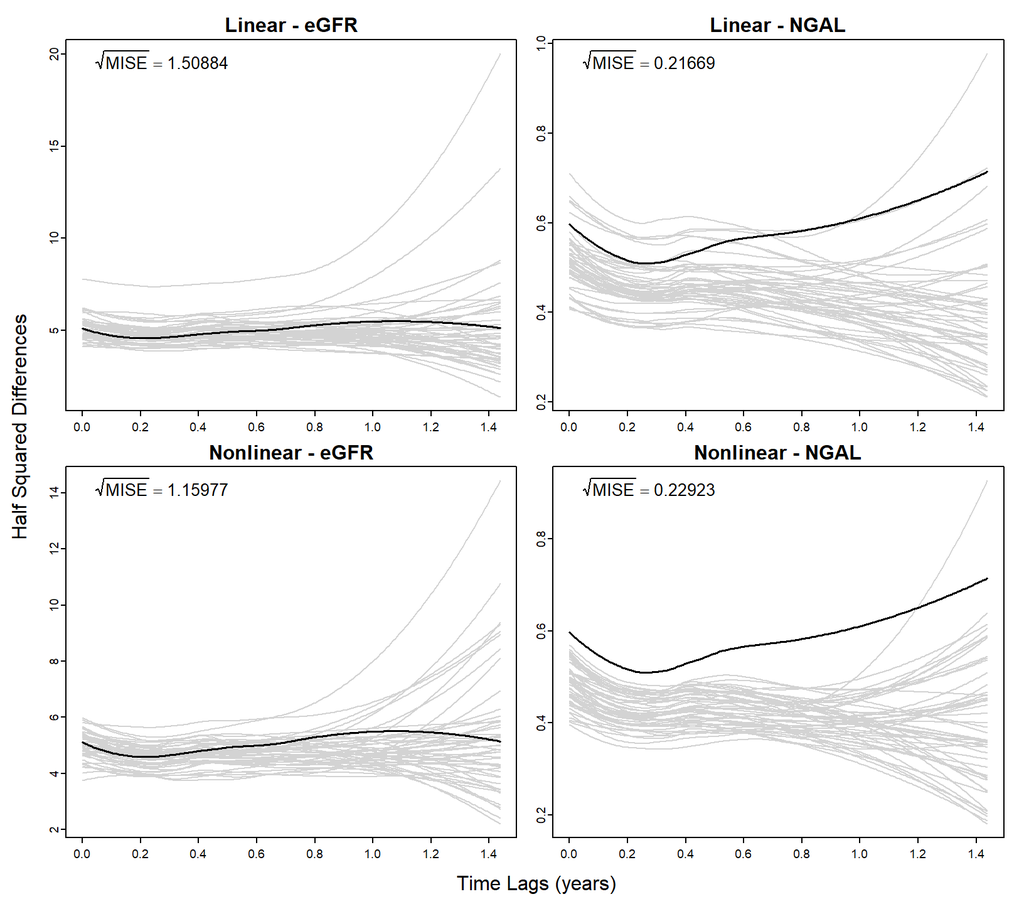

## 1.11 Longitudinal Models: Cross-Validated Dynamic-Posterior-Posterior Checks at landmark time t_L = 2

- The four tabs show the empirical cumulative distribution, mean, variance, and semi-variogram functions for the two fitted joint models using the current value functional form. The results from the area/integral functional form were very similar.
- In each figure and for the two longitudinal outcomes, we compare the observed data metric (black line) with the same metric calculated in 50 simulated datasets from the corresponding model (grey lines) using longitudinal information up to the landmark time $t_L = 2$ years.
- The simulated datasets have been generated using the cross-validation procedure described in the main paper using $V = 10$ folds.

### 1.11.1 ECDF

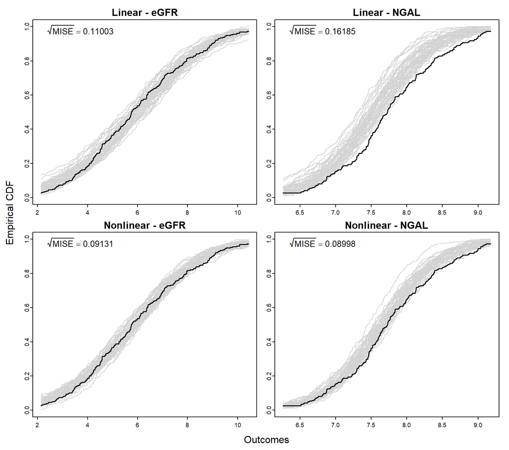

### 1.11.2 Mean Function

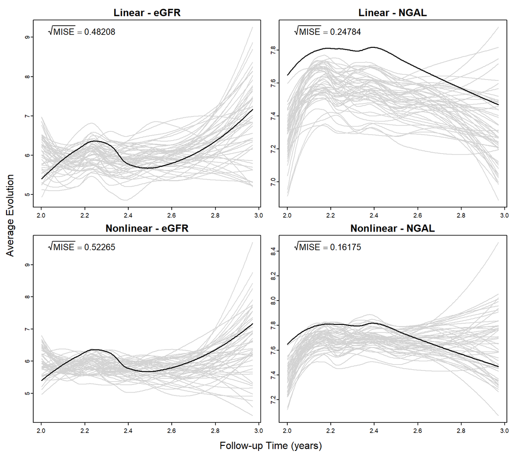